# Variable Combinations

# Data

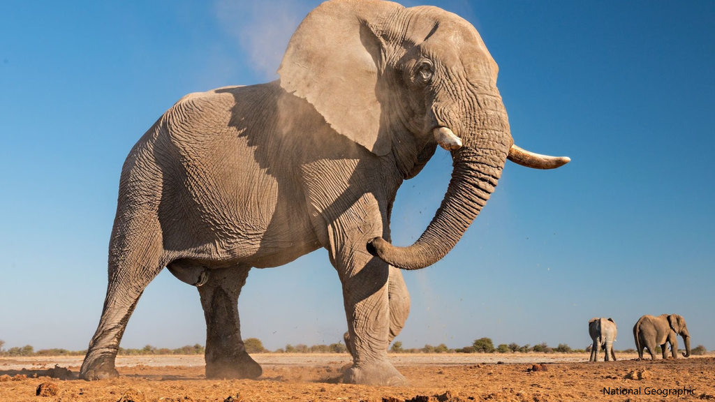

```
##     weight age.years        lat   site
## 1 12615.13        41   2.690077 Site 1
## 2 12539.55        50   2.974857 Site 2
## 3 13753.97        21  -4.868759 Site 1
## 4 17269.26        50 -28.437431 Site 2
## 5 16945.27        16 -26.414605 Site 1
## 6 14723.24        39 -11.392111 Site 2
```

# Questions

### 1. What model syntax allows for the effect of age.years to be different at each level of site?

```r
first = glm(weight~age.years+site+age.years:site)
second = glm(weight~age.years+site)
third = glm(weight~age.years*site)
fourth = glm(weight~poly(age.years,2)+site
```

**The First and Third (same model/design matrix, but different code syntax) allow the effect of slope to be different at each level of site. These are interactions b/w variables, such that the variables co-depend on each other.**

**The Second allows there to be a site-level differences but the same slope**

**The fourth also allows a site level difference of a quadratic effect, but the same quadratic effect**

**Main take away - all allow for different effects of age.years by site, but the First and Third let the effect/slope be different, while the other models just move the same slope up and down due to site.**

### 2. Draw an x-y plot showing the relationship b/w weight and the additive effect of site and age.years. Assume a negative slope of age.years with weight and two levels of the variable site. Assume the intercept mle is 13000 and the estimated effect of siteSite2 = -2000. Label axes and slopes for each site.

```r
glm(weight~age.years+site)
```

**The plot should have weight on the y-axis and age.years on the x-axis. There should be two lines, representing the slopes of age.years for each site. The slopes should be parallel with site 2 lower than site 1. The slope for site 2 should be lower on the y-axis than site 1.**

### 3. Looking at the data table above, write out the design matrix for the two models below.

```r
glm(weight~age.years+site)
glm(weight~age.years*site)
```

```
##   (Intercept) age.years siteSite 2
## 1           1        41          0
## 2           1        50          1
## 3           1        21          0
## 4           1        50          1
## 5           1        16          0
## 6           1        39          1
```

```
##   (Intercept) age.years siteSite 2 age.years:siteSite 2
## 1           1        41          0                    0
## 2           1        50          1                   50
## 3           1        21          0                    0
## 4           1        50          1                   50
## 5           1        16          0                    0
## 6           1        39          1                   39
```

### 4. When might it be good to assume an additive effect b/w a categorical and continuous variable over an interaction?

**When there are many levels of the categorical variable and not a lot of replicate data at each or some levels. Also, when the hypothesis is an effect of difference by each level, but the same slope.**

### 5. Define what each coefficient means. Make sure to make clear the units.

```r
dat$age.years.sc = scale(dat$age.years,center=TRUE, scale=FALSE)
summary(glm(weight~age.years.sc*site,data=dat))
```

```
##
## Call:
## glm(formula = weight ~ age.years.sc * site, data = dat)
##
## Coefficients:
##                         Estimate Std. Error t value Pr(>|t|)
## (Intercept)             14574.77     241.92  60.245  < 2e-16 ***
## age.years.sc              -65.32      24.35  -2.682  0.00861 **
## siteSite 2               -188.06     342.00  -0.550  0.58367
## age.years.sc:siteSite 2   108.48      32.14   3.375  0.00107 **
## ---
## Signif. codes:  0 '***' 0.001 '**' 0.01 '*' 0.05 '.' 0.1 ' ' 1
##
## (Dispersion parameter for gaussian family taken to be 2908337)
##
##     Null deviance: 313494594  on 99  degrees of freedom
## Residual deviance: 279200364  on 96  degrees of freedom
## AIC: 1778
##
## Number of Fisher Scoring iterations: 2
```

**Intercept = the mean weight of elephants at the observed mean age of elephants at site 1**

**age.yeras.sc = the one year change in mean weight of elephants at site 1**

**siteSite 2 = the mean weight effect difference of site 2 from site 1 (intercept) at the mean observed age of elephants.**

**age.yeras.sc:siteSite 2 - the change in the slope or one year change in mean weight of elephants at site 2 from site 1**

### 6. Is this a statement about data or the parameters?

$$[\textbf{y}|\mathbf{\theta}]$$

**It is a statement about the data. If we know what $\theta$ is than it is the probability of observing the data ($\textbf{y}$), given $\theta$. If we do not know what $\theta$ is than it is likelihood of observing the data ($\textbf{y}$), given our guess of $\theta$.**

### 7. Would you like your statistical analysis make a statement about your data or about the parameters?

**I personally want to know about the probability of an unknown parameter, given the data we observe because it is the reason why I am fitting a model to data. I can learn about parameters either way, but the parameters is my focus and quantity of interest, so I’d rather make statements directly about them.**